# US Storm Consequences

Phillip Chaffee

Wednesday, July 22, 2015

## Synopsis

This analysis attempts to use the National Weather Service’s Storm Data Documentation to answer two questions about US storms.

Which storm types are the most harmful with respect to population health?

Which storm types have the greatest economic consequences?

The study found that the storm types with the greatest health consequences are tornado, thunderstorm wind, flood, flash flood, heat, excessive heat, and lightning.

The storm types with the greatest economic consequences are drought, flood, flash flood, hail, extreme cold, frost/freeze, tornado, and hurricane.

## Data Processing

In this section we will take our raw data and transform it into something we can easily work with to answer our questions.

First, we will download and store the data.

```r
download.file("http://d396qusza40orc.cloudfront.net/repdata%2Fdata%2FStormData.csv.bz2", destfile="StormData.csv.bz2")

stormdata <- read.csv(bzfile("StormData.csv.bz2"), stringsAsFactors=F)
```

What variables do we have to work with?

```r
colnames(stormdata)
```

```
##  [1] "STATE__"    "BGN_DATE"   "BGN_TIME"   "TIME_ZONE"  "COUNTY"
##  [6] "COUNTYNAME" "STATE"      "EVTYPE"     "BGN_RANGE"  "BGN_AZI"
## [11] "BGN_LOCATI" "END_DATE"   "END_TIME"   "COUNTY_END" "COUNTYENDN"
## [16] "END_RANGE"  "END_AZI"    "END_LOCATI" "LENGTH"     "WIDTH"
## [21] "F"          "MAG"        "FATALITIES" "INJURIES"   "PROPDMG"
## [26] "PROPDMGEXP" "CROPDMG"    "CROPDMGEXP" "WFO"        "STATEOFFIC"
## [31] "ZONENAMES"  "LATITUDE"   "LONGITUDE"  "LATITUDE_E" "LONGITUDE_"
## [36] "REMARKS"    "REFNUM"
```

```r
head(stormdata)
```

```
##   STATE__           BGN_DATE BGN_TIME TIME_ZONE COUNTY COUNTYNAME STATE
## 1       1  4/18/1950 0:00:00     0130       CST     97     MOBILE    AL
## 2       1  4/18/1950 0:00:00     0145       CST      3    BALDWIN    AL
## 3       1  2/20/1951 0:00:00     1600       CST     57    FAYETTE    AL
## 4       1   6/8/1951 0:00:00     0900       CST     89    MADISON    AL
## 5       1 11/15/1951 0:00:00     1500       CST     43    CULLMAN    AL
## 6       1 11/15/1951 0:00:00     2000       CST     77 LAUDERDALE    AL
##    EVTYPE BGN_RANGE BGN_AZI BGN_LOCATI END_DATE END_TIME COUNTY_END
## 1 TORNADO         0                                               0
## 2 TORNADO         0                                               0
## 3 TORNADO         0                                               0
## 4 TORNADO         0                                               0
## 5 TORNADO         0                                               0
## 6 TORNADO         0                                               0
##   COUNTYENDN END_RANGE END_AZI END_LOCATI LENGTH WIDTH F MAG FATALITIES
```

[output cut: 20 more lines]

We need the variables that have to do with storm type, health effects, and economic effects. These seem to be EVTYPE, FATALITIES, INJURIES, PROPDMG, PROPDMGEXP, CROPDMG, and CROPDMGEXP. So let’s subset to a data set with only those variables.

```r
columns <- c("EVTYPE", "FATALITIES", "INJURIES", "PROPDMG", "PROPDMGEXP", "CROPDMG", "CROPDMGEXP")
stormdata <- stormdata[,columns]
head(stormdata)
```

```
##    EVTYPE FATALITIES INJURIES PROPDMG PROPDMGEXP CROPDMG CROPDMGEXP
## 1 TORNADO          0       15    25.0          K       0
## 2 TORNADO          0        0     2.5          K       0
## 3 TORNADO          0        2    25.0          K       0
## 4 TORNADO          0        2     2.5          K       0
## 5 TORNADO          0        2     2.5          K       0
## 6 TORNADO          0        6     2.5          K       0
```

It also seems that the damage numbers need to be multiplied by their corresponding exponent. Let’s do that and shrink the data set even more.

```r
for(i in 1:length(stormdata$EVTYPE)) {
  if(stormdata[i,5]=="K"){
    stormdata[i,4] <- stormdata[i,4]*1000
  }else if(stormdata[i,7]=="K"){
    stormdata[i,6] <- stormdata[i,6]*1000
  }
  if(stormdata[i,5]=="M"){
    stormdata[i,4] <- stormdata[i,4]*1000000
  }else if(stormdata[i,7]=="M"){
    stormdata[i,6] <- stormdata[i,6]*1000000
  }
}

columns <- c("EVTYPE", "FATALITIES", "INJURIES", "PROPDMG", "CROPDMG")
stormdata <- stormdata[,columns]
head(stormdata)
```

```
##    EVTYPE FATALITIES INJURIES PROPDMG CROPDMG
## 1 TORNADO          0       15   25000       0
## 2 TORNADO          0        0    2500       0
## 3 TORNADO          0        2   25000       0
## 4 TORNADO          0        2    2500       0
## 5 TORNADO          0        2    2500       0
## 6 TORNADO          0        6    2500       0
```

We now have a clean data set with only the variables we need to work with.

## Data Analysis

Which storm types are the most harmful with respect to population health?

```r
injuries <- aggregate(INJURIES ~ EVTYPE, sum, data=stormdata, na.action=na.omit)
fatalities <- aggregate(FATALITIES ~ EVTYPE, sum, data=stormdata, na.action=na.omit)

injuries<- injuries[order(-injuries$INJURIES),]
injuries<- injuries[1:5,]

fatalities <- fatalities[order(-fatalities$FATALITIES),]
fatalities <- fatalities[1:5,]
```

Which storm types have the greatest economic consequences?

```r
propdmg <- aggregate(PROPDMG ~ EVTYPE, sum, data=stormdata, na.action=na.omit)
cropdmg <- aggregate(CROPDMG ~ EVTYPE, sum, data=stormdata, na.action=na.omit)

propdmg <- propdmg[order(-propdmg$PROPDMG),]
propdmg <- propdmg[1:5,]

cropdmg <- cropdmg[order(-cropdmg$CROPDMG),]
cropdmg <- cropdmg[1:5,]
```

## Results

#### Which storm types are the most harmful with respect to population health?

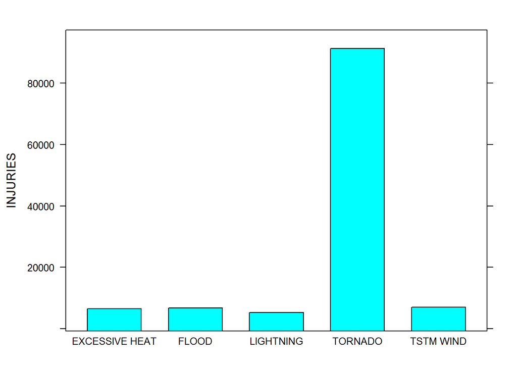

```r
library(lattice)
barchart(INJURIES ~ EVTYPE, injuries)
```

The top five storms types for injuries are tornado, thunderstorm wind, lightning, flood, and excessive heat.

The fatality data is a bit different, but mostly the same. Here are the exact numbers.

```r
injuries
```

```
##             EVTYPE INJURIES
## 834        TORNADO    91346
## 856      TSTM WIND     6957
## 170          FLOOD     6789
## 130 EXCESSIVE HEAT     6525
## 464      LIGHTNING     5230
```

```r
fatalities
```

```
##             EVTYPE FATALITIES
## 834        TORNADO       5633
## 130 EXCESSIVE HEAT       1903
## 153    FLASH FLOOD        978
## 275           HEAT        937
## 464      LIGHTNING        816
```

#### Which storm types have the greatest economic consequences?

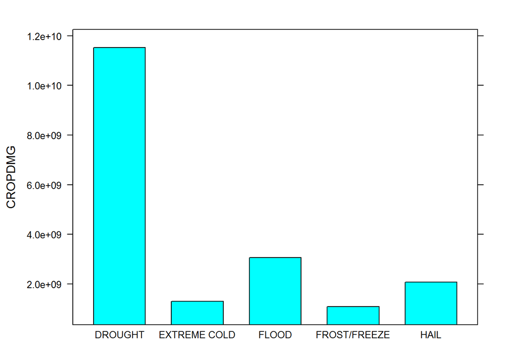

```r
barchart(CROPDMG ~ EVTYPE, cropdmg)
```

The worst thing for crops is drought.

Let’s take a look at the exact numbers on crop damage and property damage by storm type.

```r
cropdmg
```

```
##           EVTYPE     CROPDMG
## 95       DROUGHT 11529785146
## 170        FLOOD  3069098755
## 244         HAIL  2074260070
## 140 EXTREME COLD  1292868105
## 212 FROST/FREEZE  1083390706
```

```r
propdmg
```

```
##          EVTYPE     PROPDMG
## 834     TORNADO 51625660796
## 170       FLOOD 22157709930
## 153 FLASH FLOOD 15140812068
## 244        HAIL 13927367054
## 402   HURRICANE  6168319016
```